# Beltrame_Ginevra_Rlab02

2024-04-16

## Exercise 1 - Discrete random variable

The probability distribution function of a discrete variable k is given by the zero-truncated Poisson distribution.

### Part 1) Write the R functions for the probability density and cumulative distribution functions, using the R naming convention.

```r
x_max <- 15
x <- 1:x_max
lambda <- 1.4
pdf_function <- dpois(x, lambda)  # naming convention: use the letter d for the pdf
cdf_function <- ppois(x, lambda)  # and p for the cdf
```

### Part 2) Produce two plots showing the pdf and cdf, separately.

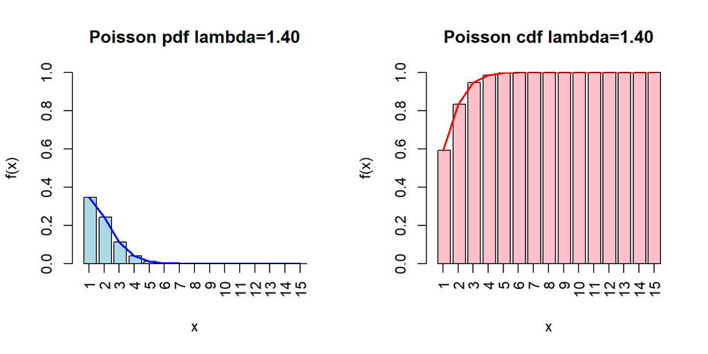

```r
par(mfrow = c(1, 2))

barplot(pdf_function, col = "lightblue", xlab='x', xlim=c(0,x_max), ylim=c(0,1), ylab='f(x)', main = sprintf("Poisson pdf lambda=%.2f",lambda), width=rep(0.83, x_max))
lines(x-rep(0.5, x_max), pdf_function, col="blue", lw=2)
xticks <- seq(0.5, x_max-0.5, 1)
xticklabels <- seq(1, x_max, 1)
axis(side = 1, at = xticks, labels = xticklabels, las = 2)

barplot(cdf_function, col = "pink", xlab='x', ylab='f(x)', xlim=c(0,x_max), ylim=c(0,1), main = sprintf("Poisson cdf lambda=%.2f",lambda), width=rep(0.83, x_max))
lines(x-rep(0.5, x_max), cdf_function, col="red", lw=2)
xticks <- seq(0.5, x_max-0.5, 1)
xticklabels <- seq(1, x_max, 1)
axis(side = 1, at = xticks, labels = xticklabels, las = 2)
```

```r
par(mfrow = c(1, 1))
```

### Part 3) Compute the mean value and variance of the probability distribution using R.

```r
mean_pdf <- mean(pdf_function)
var_pdf <- var(pdf_function)

print(paste('The mean of the pdf is', round(mean_pdf, digits=2), 'while the variance is', round(var_pdf, digits=2),'.'))
```

```
## [1] "The mean of the pdf is 0.05 while the variance is 0.01 ."
```

### Part 4) Generate a sample of random numbers from this distribution and show them in an histogram. Evaluate the sample mean.

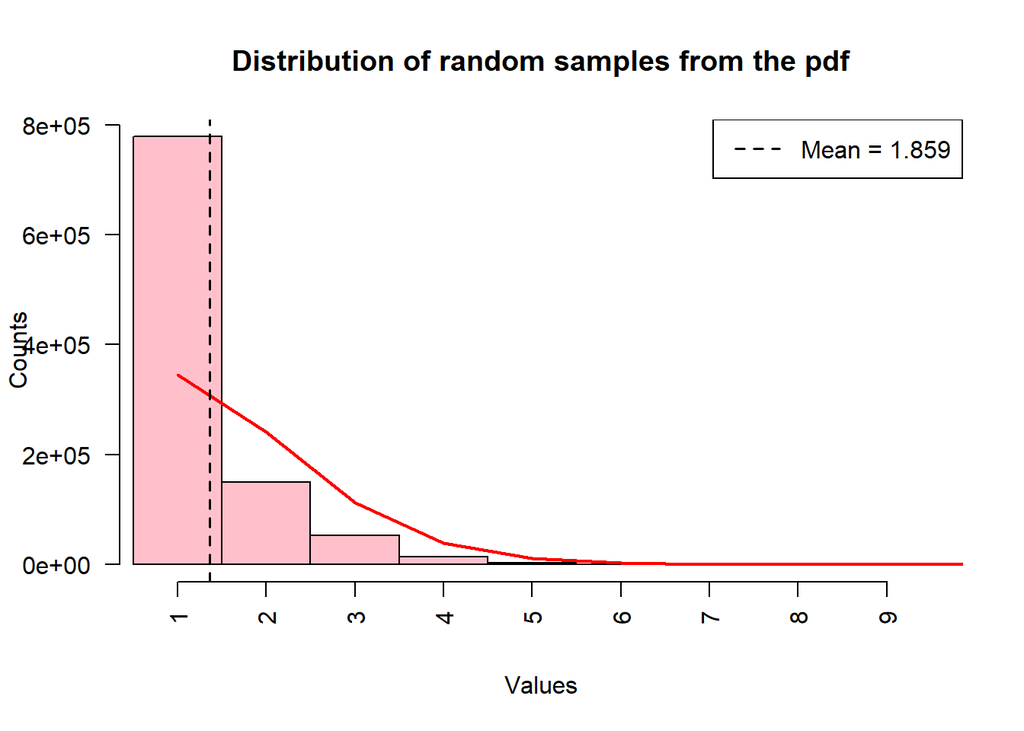

```r
N_samples <- 1000000
samples <- sample(x, N_samples, replace=TRUE, prob=pdf_function)

hist(samples, breaks = seq(min(samples), max(samples), 1), main='Distribution of random samples from the pdf',
     xlab='Values', ylab='Counts', col='pink', axes=FALSE, xlim=c(min(samples)+0.2, max(samples)))
xticks <- seq(1.5, max(samples)-0.5, 1)
xticklabels <- seq(1, max(samples)-1, 1)
axis(side = 1, at = xticks, labels = xticklabels, las = 2)
axis(side = 2, at = pretty(0:N_samples*0.8), labels = TRUE, las = 1)
lines(x+rep(0.5, x_max), N_samples*pdf_function, col="red", lw=2)


abline(v = mean(samples), col = "black", lty = 2, lw = 1.5)
legend("topright", legend = sprintf("Mean = %.3f", mean(samples)), col = "black", lty = 2, lw = 1.5)
```

## Exercise 2 - Continuous random variable

### Part a) Compute the normalization factor N using R.

```r
E0 <- 7.25
gamma <- 2.7

p1 <- E0
p2.integral <- integrate(function(E) {(E-E0+1)^(-gamma)}, lower=E0, upper=Inf)

N <- 1/(p1 + p2.integral$value)

print(paste("The normalization factor is N =", round(N, digits=3)))
```

```
## [1] "The normalization factor is N = 0.128"
```

### Part b) Plot the probability density function in R.

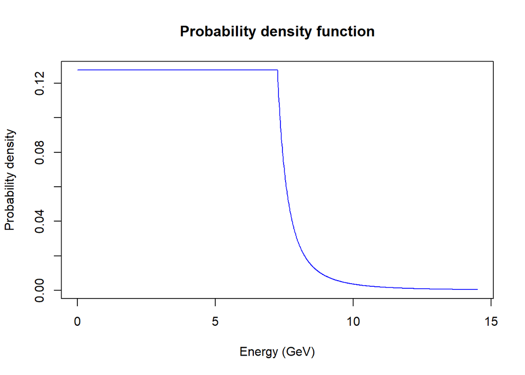

```r
pdf_function <- function(E) {
  if (E < E0) {
    return(N)
  }
  else {
    return(N*(E - E0 + 1)^(-gamma))
  }
}

step <- 0.01

x <- seq(0, 2*E0, step)
pdf_values <- sapply(x, pdf_function)

plot(x, pdf_values, col='blue', type='l', xlab = "Energy (GeV)", ylab = "Probability density", main = "Probability density function")
```

### Part c) Plot the cumulative density function in R.

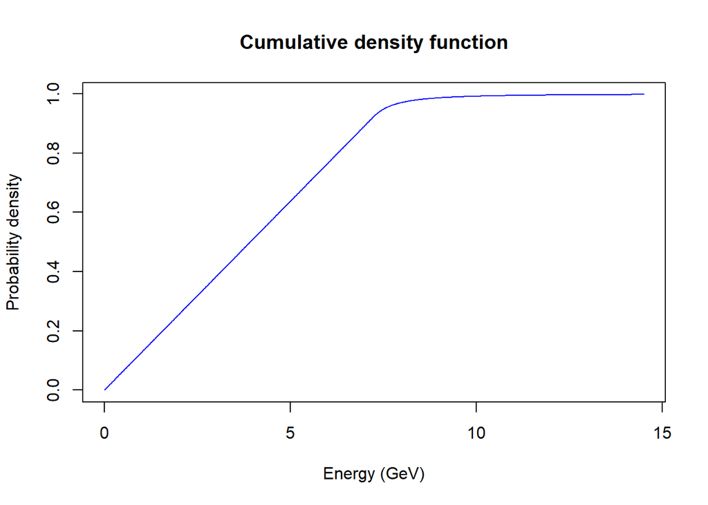

```r
cdf_function <- function(E) {
  if (E == 0){
    return(0)
  }
  else if (E <= E0) {
    return(N*E)
  }
  else if (E > E0) {
    return(E0*N + integrate(function(E) {N*(E - E0 + 1)^(-gamma)}, lower=E0, upper=E)$value)
  }
}

cdf_values <- sapply(x, cdf_function)

plot(x, cdf_values, col='blue', type='l', xlab = "Energy (GeV)", ylab = "Probability density", main = "Cumulative density function")
```

### Part d) Compute the mean value using R.

```r
mean_value <- sum(x*pdf_values*step)

print(paste('The mean value is', signif(mean_value, 4)))
```

```
## [1] "The mean value is 3.95"
```

### Part e) [Optional] Generate $10^6$ random numbers from this distribution, show them in an histogram and superimpose the pdf (with a line or with a sufficient number of points).

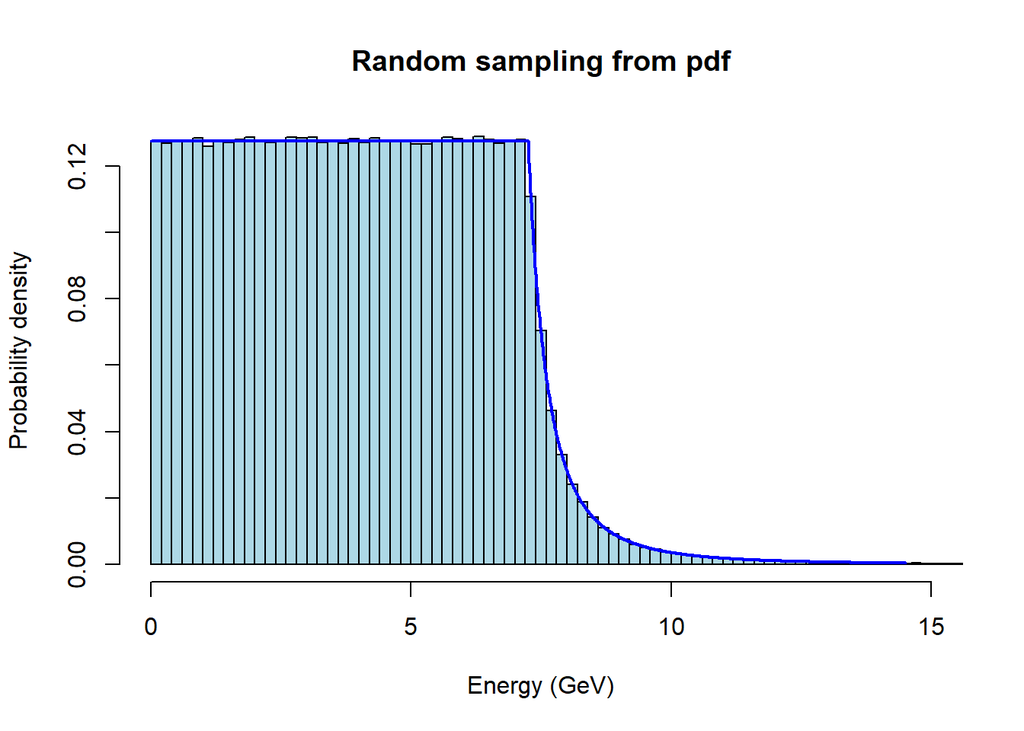

```r
n_samples <- 10^6
unif_sample <- runif(n_samples, 0, 1)

icdf_function <- function(y) {
  if (y < N*E0) {
    return(y/N)
  }
  else if (y >= N*E0 & y<=1) {
    return(((1-gamma)*(y/N - E0) + 1)^(1/(1-gamma)) + E0 - 1)
  }
}

pdf_samples <- sapply(unif_sample, icdf_function)

hist(pdf_samples, breaks=max(pdf_samples)*5, freq=FALSE, xlim=c(0,15), col='lightblue', xlab='Energy (GeV)', ylab='Probability density', main='Random sampling from pdf')
lines(x, pdf_values, col='blue', lwd=2)
```

## Exercise 3 - Accidents at an intersection

Suppose that the average number of accidents at an intersection is two per day.

### Part a) Using Markov’s inequality, find a bound for the probability that at least five accidents will occur tomorrow.

$$P(X \geq k) \leq \frac{\mu}{k} \quad \forall \ k>0, \quad \text{where
} X \text{ is a non-negative random variable with } E[x] = \mu$$

```r
mu <- 2
k <- 5
P_Markov <- mu/k
print(paste("The bound is", P_Markov))
```

```
## [1] "The bound is 0.4"
```

### Part b) Using Poisson random variables, calculate the probability that at least five accidents will occur tomorrow. Compare this value with the bound obtained in the previous point a).

```r
lambda <- 2
t <- 1
n_min <- 5
P_Poisson_opposites <- numeric(n_min)

for (n in 1:n_min) {
  P_Poisson_opposites[n] <- (lambda*t)^(n-1) * exp(-lambda*t)/factorial(n-1)
  # print(P_Poisson_opposites[n])
}

P_Poisson <- 1 - sum(P_Poisson_opposites)
print(paste("The probability is", signif(P_Poisson, digits=3), "which is within the bound", P_Markov))
```

```
## [1] "The probability is 0.0527 which is within the bound 0.4"
```

### Part c) Let the variance of the number of accidents be two per day. Using Chebyshev’s inequality, find a bound on the probability that tomorrow at least five accidents will occur.

$$P(|X-\mu| \geq k) \leq \frac{\sigma^2}{k^2} \quad \forall \ k>0,
\quad \text{where } X \text{ is a non-negative random variable with }
E[x] = \mu \text{ and } Var(x)=\sigma$$

```r
variance <- 2
mu <- 2
X_target <- 5
k <- X_target - mu
P_Cheb <- variance/k^2
print(paste("The bound according to Chebyshev's inequality is", signif(P_Cheb, 3)))
```

```
## [1] "The bound according to Chebyshev's inequality is 0.222"
```

## Exercise 4 - Book ordering time

The waiting period from the time a book is ordered until it is received is a random variable with mean seven days and standard deviation two days. If Helen wants to be 95% sure that she receives a book by certain date, how early should she order the book?

```r
mu <- 7
sigma <- 2
prob <- 0.95
k_bound <- sigma/sqrt(1-prob) + mu
days <- ceiling(k_bound)

print(paste("Using Chebyshev's inequality, we find that Helen should order the book at least", days, "days earlier."))
```

```
## [1] "Using Chebyshev's inequality, we find that Helen should order the book at least 16 days earlier."
```

## Exercise 5 - Deck of cards

An ordinary deck of 52 cards is divided randomly into 26 pairs. Using Chebyshev’s inequality, find an upper bound for the probability that, at most, 10 pairs consist of a black and a red card.

### Solution (1) - Hypergeometric distribution

The probability distribution of the number of $(B, R)$ and $(R, B)$ pairs follows a hypergeometruc distribution, where we identify with $N=\binom{52}{2}=1326$ the total number of possible pairs and with $B=26\cdot26=676$ the number of different-colour pairs. Moreover, $n=26$ is the number of drawn samples.

$$P(x|N,B,n) = \frac{\binom{B}{x} \binom{N-B}{n-x}}{\binom{N}{n}} \quad
\text{with} \quad E[x]=\frac{nB}{N}, \ Var(x) =
\frac{nB(N-B)}{N^2}(1-\frac{n-1}{N-1})$$

```r
n <- 26
N <- 51*52/2
B <- 26*26

mu <- n*B/N
v <- n*B*(N-B)/N^2 * (1 - (n-1)/(N-1))

# Chebyshev's inequality
X_target <- 10
k <- X_target - mu
P_Cheb <- v/k^2
print(paste("The bound according to Chebyshev's inequality is", signif(P_Cheb, 3)))
```

```
## [1] "The bound according to Chebyshev's inequality is 0.602"
```

### Solution (2) - Simulation

```r
deck <- c(rep(1, 26), rep(0, 26)) # 0s are the black cards and 1s are the red cards
n_samples <- 10^5
pairs <- rep(numeric(2), 26)
number_br_pairs <- rep(0, n_samples)

for (n in 1:n_samples){
  shuffle_deck <- sample(deck)
  pairs <- split(shuffle_deck, ceiling(seq_along(shuffle_deck) / 2))
  for (i in 1:26){
    number_br_pairs[n] <- number_br_pairs[n] + sum(pairs[[i]])%%2
  }
}

mu <- mean(number_br_pairs)
v <- var(number_br_pairs)

# Chebyshev's inequality
X_target <- 10
k <- X_target - mu
P_Cheb <- v/k^2
print(paste("The bound according to Chebyshev's inequality is", signif(P_Cheb, 3)))
```

```
## [1] "The bound according to Chebyshev's inequality is 0.615"
```

## Exercise 6 - Bus station

In a stationary bus at the departure station, a passenger gets on the bus, on average every 30 seconds.

### Part a) Compute the probability of getting more than 6 passengers after 2 minutes. Evaluate the probability of having less than 4 passengers after 3 minutes.

The passengers getting on the bus is assumed to be a Poisson process (unrelated rare events), therefore the requests above can be written as in the following. Specifically, it is assumed that $\lambda = \frac{1}{30 \ \text{s}}$.

$$P(N(t=2 \ \text{min}) > 6) = 1 - \sum_{j=0}^{6} \frac{(\lambda t)^j
e^{-\lambda t}}{j!} = 1 - \sum_{j=0}^{6} \frac{4^j e^{-4}}{j!} = 1 -
e^{-4}(1 + 4 + \frac{16}{2} + \frac{64}{6} + \frac{256}{24} +
\frac{1024}{120} + \frac{4096}{720}) \approx 0.111 \\
P(N(t=3 \ \text{min}) < 4) = \sum_{j=0}^{3} \frac{(\lambda t)^j
e^{-\lambda t}}{j!} = \sum_{j=0}^{3} \frac{6^j e^{-6}}{j!} = e^{-6}(1 +
6 + \frac{36}{2} + \frac{216}{6}) \approx 0.151$$

This can also be computed in R.

```r
# time unit is 30 seconds
lambda <- 1/30
t1 <- 2*60

print(paste('The probability of getting more than 6 passengers after 2 minutes is', signif(1-ppois(6,lambda*t1), 3), '.'))
```

```
## [1] "The probability of getting more than 6 passengers after 2 minutes is 0.111 ."
```

```r
t2 <- 3*60

print(paste('The probability of getting less than 4 passengers after 3 minutes is', signif(ppois(3,lambda*t2), 3), '.'))
```

```
## [1] "The probability of getting less than 4 passengers after 3 minutes is 0.151 ."
```

### Part b) Simulate the distribution of the arrival time of the third passenger and superimpose the corresponding pdf.

Assuming that the first two passengers have already gotten on the bus, the arrival time of the third follows the Erlang probability distribution, a Gamma distribution $Gamma(n, \lambda)$ so that the first parameter is an integer. In this case, calling $t_3$ the time of the third event ($n=3$), we get

$$\text{pdf}(t_3) = Gamma(n=3, \lambda=\frac{1}{30})(t_3) =
\frac{t_3^{n-1} \lambda^n e^{-\lambda t_3}}{(n-1)!} = \frac{t_3^2 \ e^{-
\frac{t_3}{30}}}{2 \cdot 30^3}$$

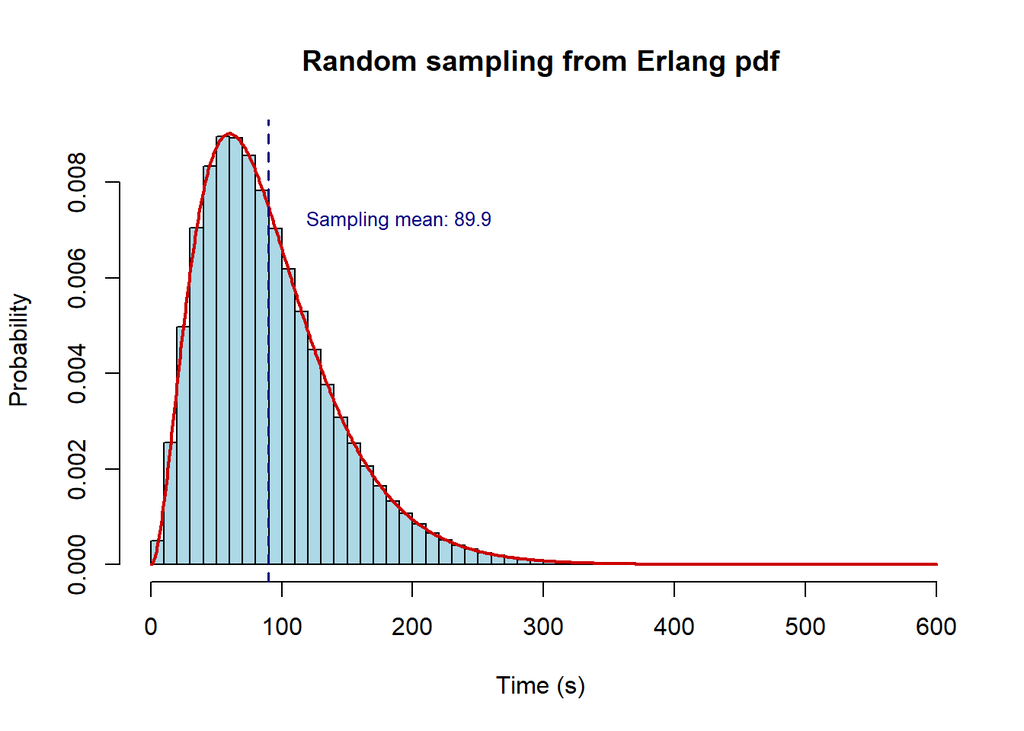

```r
n <- 3
lambda <- 1/30

## sampling
unif_samples <- runif(10^6, 0, 1)
erlang_icdf <- function(x){
  return(qgamma(x, n, lambda))
}

erlang_samples <- sapply(unif_samples, erlang_icdf)
hist(erlang_samples, breaks=max(erlang_samples)/10, freq=FALSE, xlim=c(0,max(erlang_samples)), col='lightblue', xlab='Time (s)', ylab='Probability', main='Random sampling from Erlang pdf')

## pdf drawing
erlang_pdf <- function(t){
  return(dgamma(t, n, lambda))
}

t_3 <- seq(0, 10*60, 1)
pdf_3 <- sapply(t_3, erlang_pdf)
lines(t_3, pdf_3, type='l', col='red3', lwd=2)

## mean and variance
erlang_mean <- mean(erlang_samples)
abline(v=erlang_mean, lwd=1.5, lty=2, col='navy')
text(erlang_mean+100, max(pdf_3)*0.8, paste('Sampling mean:', signif(erlang_mean, 3)), cex=0.8, col='navy')
```

### Part c) Repeat the procedure of the point b) for the difference in arrival time between the fifth and the first passenger.

$$\text{pdf}(t_{5,1}) = Gamma(n=4, \lambda=\frac{1}{30})(t) = \frac{t^3
\lambda^4 e^{-\lambda t}}{3!}$$

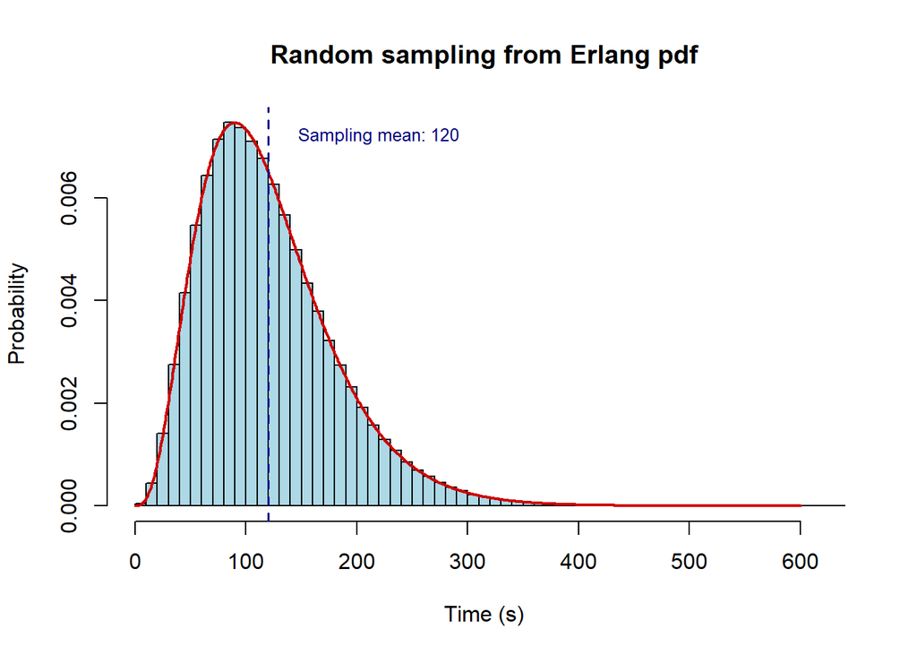

```r
n <- 4
lambda <- 1/30

## sampling
unif_samples <- runif(10^6, 0, 1)
erlang_icdf <- function(x){
  return(qgamma(x, n, lambda))
}

erlang_samples <- sapply(unif_samples, erlang_icdf)
hist(erlang_samples, breaks=max(erlang_samples)/10, freq=FALSE, xlim=c(0,max(erlang_samples)), col='lightblue', xlab='Time (s)', ylab='Probability', main='Random sampling from Erlang pdf')

## pdf drawing
erlang_pdf <- function(t){
  return(dgamma(t, n, lambda))
}

t <- seq(0, 10*60, 1)
pdf_values <- sapply(t, erlang_pdf)
lines(t, pdf_values, type='l', col='red3', lwd=2)

## mean and variance
erlang_mean <- mean(erlang_samples)
abline(v=erlang_mean, lwd=1.5, lty=2, col='navy')
text(erlang_mean+100, max(pdf_3)*0.8, paste('Sampling mean:', signif(erlang_mean, 3)), cex=0.8, col='navy')
```